# project logistic regression

Anastasia Molotova

01. Ноябрь 2020

# Load the data

Run the following line to start working:

```r
data <- readRDS("ruwvs")
str(data)
```

```
## 'data.frame':    1810 obs. of  10 variables:
##  $ Q211      : Factor w/ 2 levels "0","1": 1 1 1 2 1 1 2 2 2 2 ...
##  $ intinpol  : Factor w/ 4 levels "Very interested",..: 4 2 2 3 3 3 3 2 3 4 ...
##  $ eduR      : Factor w/ 4 levels "Primary","Secondary",..: 3 4 4 4 4 2 2 2 4 2 ...
##  $ townsize  : Factor w/ 5 levels "Under 5,000",..: 5 5 5 5 5 4 4 4 5 5 ...
##  $ settlement: Factor w/ 5 levels "Capital city",..: 1 1 1 2 2 2 2 2 1 1 ...
##  $ income    : Factor w/ 10 levels "Lower step","second step",..: 8 6 6 3 4 3 6 4 5 9 ...
##  $ region    : Factor w/ 8 levels "RU: North West Federal District",..: 2 2 2 4 4 2 2 2 2 2 ...
##  $ age       : Factor w/ 85 levels "16","17","18",..: 21 43 27 32 46 54 25 63 36 13 ...
##  $ income1   : num  7 5 5 2 3 2 5 3 4 8 ...
##  $ eduT      : Factor w/ 2 levels "0","1": 1 2 2 2 2 1 1 1 2 1 ...
```

```r
head(data)
```

```
##   Q211              intinpol           eduR        townsize      settlement
## 1    0 Not at all interested Post-secondary 500000 and more    Capital city
## 2    0   Somewhat interested       Tertiary 500000 and more    Capital city
## 3    0   Somewhat interested       Tertiary 500000 and more    Capital city
## 4    1   Not very interested       Tertiary 500000 and more Regional center
## 5    0   Not very interested       Tertiary 500000 and more Regional center
## 6    0   Not very interested      Secondary   100000-500000 Regional center
##        income                                  region age income1 eduT
## 1 Eight  step            RU: Central Federal District  36       7    0
## 2  Sixth step            RU: Central Federal District  58       5    1
## 3  Sixth step            RU: Central Federal District  42       5    1
## 4  Third step RU: Volga; Privolzhsky Federal District  47       2    1
## 5 Fourth step RU: Volga; Privolzhsky Federal District  61       3    1
## 6  Third step            RU: Central Federal District  69       2    0
```

```r
tail(data)
```

```
##      Q211              intinpol           eduR   townsize      settlement
## 1805    1   Not very interested      Secondary 5000-20000 District center
## 1806    1       Very interested      Secondary 5000-20000 District center
## 1807    0       Very interested       Tertiary 5000-20000 District center
## 1808    0   Not very interested Post-secondary 5000-20000 District center
## 1809    0   Somewhat interested      Secondary 5000-20000 District center
## 1810    0 Not at all interested      Secondary 5000-20000 District center
##            income                          region age income1 eduT
## 1805  Fourth step RU: North West Federal District  63       3    0
## 1806  Eight  step RU: North West Federal District  67       7    0
## 1807   Sixth step RU: North West Federal District  74       5    1
## 1808   Third step RU: North West Federal District  55       2    0
## 1809 Seventh step RU: North West Federal District  30       6    0
## 1810   Fifth step RU: North West Federal District  38       4    0
```

First of all, `age` must be a numeric variable. Also, I will delete repetitive in meaning variables: I decided yo use binary education (`eduT`) and *conditionally* income as continuous variable (`income1`).

```r
library(dplyr)
data = data %>% select(-income, -eduR)
data$age = as.numeric(data$age)
```

# Descriptive statistics

I will use DataExplorer library in order to plot some info + psych for stats information.

```r
library(DataExplorer)
introduce(data)
```

```
##   rows columns discrete_columns continuous_columns all_missing_columns
## 1 1810       8                6                  2                   0
##   total_missing_values complete_rows total_observations memory_usage
## 1                   79          1736              14480        79296
```

So, here we have 79 missing values. Let’s delete them since it will not affect the results (insignificant part of the data, 79 out of 1810). More NA we have in `income`(3.48%) variable, then `education`(.55%) and `interested in politics`(.33%).

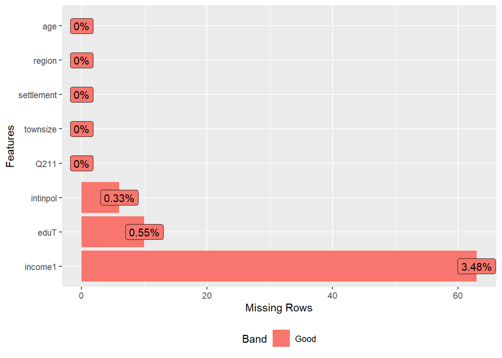

```r
plot_missing(data)
```

```r
data = na.omit(data)
```

```r
library(psych)
describe(data)
```

```
##             vars    n  mean    sd median trimmed   mad min max range  skew
## Q211*          1 1736  1.42  0.49      1    1.40  0.00   1   2     1  0.34
## intinpol*      2 1736  2.65  0.85      3    2.66  1.48   1   4     3 -0.05
## townsize*      3 1736  3.30  1.54      4    3.38  1.48   1   5     4 -0.33
## settlement*    4 1736  3.09  1.32      3    3.10  1.48   1   5     4  0.31
## region*        5 1736  4.09  2.25      4    3.98  2.97   1   8     7  0.37
## age            6 1736 30.58 17.06     29   29.81 19.27   3  76    73  0.33
## income1        7 1736  3.77  1.94      4    3.75  1.48   0   9     9  0.11
## eduT*          8 1736  1.33  0.47      1    1.29  0.00   1   2     1  0.72
##             kurtosis   se
## Q211*          -1.89 0.01
## intinpol*      -0.67 0.02
## townsize*      -1.39 0.04
## settlement*    -1.16 0.03
## region*        -1.15 0.05
## age            -0.83 0.41
## income1        -0.40 0.05
## eduT*          -1.48 0.01
```

Describing our data by target variable – answer to the question (either will do this political action or not)

```r
describeBy(data, data$Q211)
```

```
##
##  Descriptive statistics by group
## group: 0
##             vars    n  mean    sd median trimmed   mad min max range  skew
## Q211*          1 1013  1.00  0.00      1    1.00  0.00   1   1     0   NaN
## intinpol*      2 1013  2.75  0.86      3    2.77  1.48   1   4     3 -0.10
## townsize*      3 1013  3.31  1.51      4    3.38  1.48   1   5     4 -0.32
## settlement*    4 1013  3.16  1.27      3    3.14  1.48   1   5     4  0.33
## region*        5 1013  4.25  2.29      4    4.19  2.97   1   8     7  0.26
## age            6 1013 30.34 17.20     28   29.46 19.27   3  76    73  0.38
## income1        7 1013  3.80  1.93      4    3.77  1.48   0   9     9  0.13
## eduT*          8 1013  1.31  0.46      1    1.26  0.00   1   2     1  0.83
##             kurtosis   se
## Q211*            NaN 0.00
## intinpol*      -0.77 0.03
## townsize*      -1.35 0.05
## settlement*    -1.13 0.04
## region*        -1.22 0.07
## age            -0.82 0.54
## income1        -0.37 0.06
## eduT*          -1.32 0.01
## ------------------------------------------------------------
## group: 1
##             vars   n  mean    sd median trimmed   mad min max range  skew
## Q211*          1 723  2.00  0.00      2    2.00  0.00   2   2     0   NaN
## intinpol*      2 723  2.50  0.82      3    2.50  1.48   1   4     3 -0.02
## townsize*      3 723  3.30  1.59      4    3.37  1.48   1   5     4 -0.34
## settlement*    4 723  3.00  1.40      3    3.00  1.48   1   5     4  0.32
## region*        5 723  3.85  2.19      4    3.72  2.97   1   8     7  0.53
## age            6 723 30.93 16.86     30   30.30 19.27   3  75    72  0.26
## income1        7 723  3.73  1.94      4    3.72  1.48   0   9     9  0.07
## eduT*          8 723  1.36  0.48      1    1.32  0.00   1   2     1  0.58
##             kurtosis   se
## Q211*            NaN 0.00
## intinpol*      -0.54 0.03
## townsize*      -1.44 0.06
## settlement*    -1.22 0.05
## region*        -1.01 0.08
## age            -0.85 0.63
## income1        -0.45 0.07
## eduT*          -1.66 0.02
```

Describing by variables:

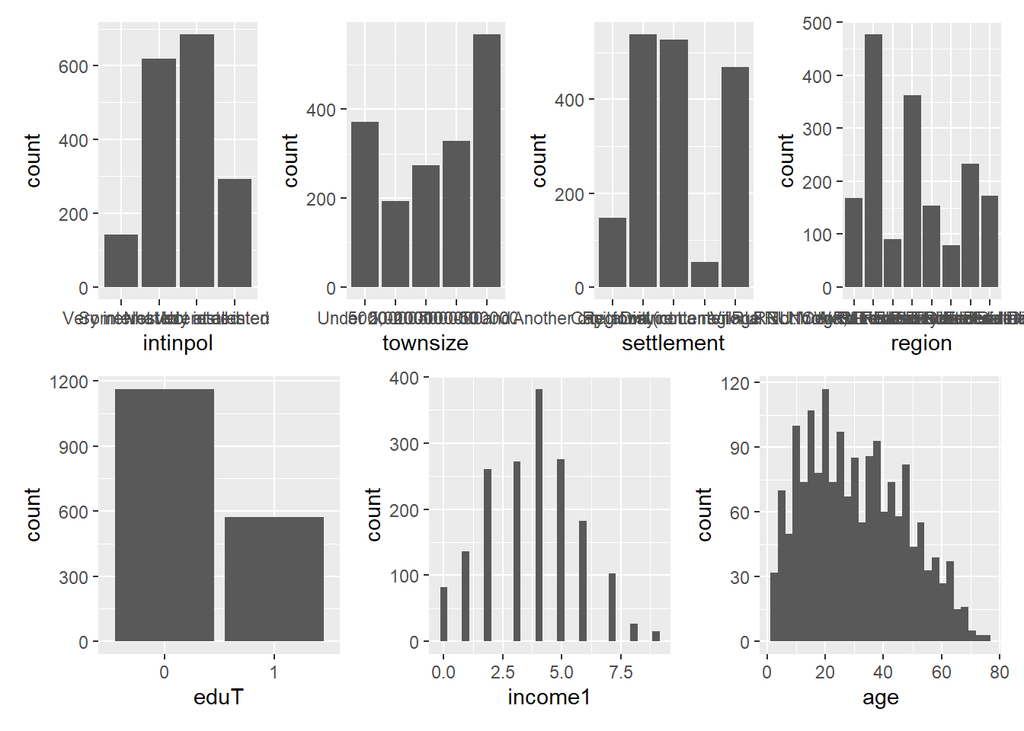

```r
library(ggplot2)

pol = ggplot()+
  geom_bar(data = data, aes(x = intinpol))
town = ggplot()+
  geom_bar(data = data, aes(x = townsize))
settle= ggplot()+
  geom_bar(data = data, aes(x = settlement))
region = ggplot()+
  geom_bar(data = data, aes(x = region))
ed = ggplot()+
  geom_bar(data = data, aes(x = eduT))

inc = ggplot()+
  geom_histogram(data = data, aes(x=income1))
ag = ggplot()+
  geom_histogram(data = data, aes(x=age))

library(patchwork)
(pol | town | settle | region ) /
      (ed | inc | ag)
```

There are some people who do not have a higher education, distribution of income is fine, but age is right-skewed.

# Modeling

First of all, I decided to make a model with all possible predictors…

```r
log <- glm(Q211 ~ ., data = data, family = "binomial")
summary(log)
```

```
##
## Call:
## glm(formula = Q211 ~ ., family = "binomial", data = data)
##
## Deviance Residuals:
##     Min       1Q   Median       3Q      Max
## -1.7841  -1.0324  -0.7212   1.1894   2.1885
##
## Coefficients:
##                                                                   Estimate
## (Intercept)                                                       3.078535
## intinpolSomewhat interested                                      -0.416313
## intinpolNot very interested                                      -0.593972
## intinpolNot at all interested                                    -1.393483
## townsize5000-20000                                               -0.975156
## townsize20000-100000                                             -0.827713
## townsize100000-500000                                            -1.409179
## townsize500000 and more                                          -2.139176
## settlementRegional center                                        -0.776317
## settlementDistrict center                                        -2.038843
## settlementAnother city, town (not a regional or district center) -2.228670
## settlementVillage                                                -2.628727
## regionRU: Central Federal District                                0.274401
## regionRU: North Caucasian federal district                        0.054545
## regionRU: Volga; Privolzhsky Federal District                     0.307681
## regionRU: Urals Federal District                                 -0.138926
## regionRU: Far East Federal District                              -0.021333
## regionRU: Siberian Federal District                               0.352633
## regionRU: South Federal District                                 -0.102461
## age                                                              -0.001177
## income1                                                          -0.049652
## eduT1                                                             0.207695
##                                                                  Std. Error
## (Intercept)                                                        0.575140
## intinpolSomewhat interested                                        0.195889
## intinpolNot very interested                                        0.195012
## intinpolNot at all interested                                      0.227852
## townsize5000-20000                                                 0.288288
## townsize20000-100000                                               0.378725
## townsize100000-500000                                              0.409723
```

[output cut: 56 more lines]

```
## regionRU: Siberian Federal District                              0.107885
## regionRU: South Federal District                                 0.690812
## age                                                              0.712634
## income1                                                          0.090913 .
## eduT1                                                            0.071190 .
## ---
## Signif. codes:  0 '***' 0.001 '**' 0.01 '*' 0.05 '.' 0.1 ' ' 1
##
## (Dispersion parameter for binomial family taken to be 1)
##
##     Null deviance: 2357.9  on 1735  degrees of freedom
## Residual deviance: 2212.8  on 1714  degrees of freedom
## AIC: 2256.8
##
## Number of Fisher Scoring iterations: 4
```

… we can clearly see that some levels are not significant, and region is not significant at all. Then I asked stepAIC for help. It goes over several models and automatically choose the best one. The best model will have the lower AIC-score.

```r
library(MASS)
stepAIC(log)
```

```
## Start:  AIC=2256.85
## Q211 ~ intinpol + townsize + settlement + region + age + income1 +
##     eduT
##
##              Df Deviance    AIC
## - region      7   2223.6 2253.6
## - age         1   2213.0 2255.0
## <none>            2212.8 2256.8
## - income1     1   2215.7 2257.7
## - eduT        1   2216.1 2258.1
## - townsize    4   2247.4 2283.4
## - settlement  4   2257.8 2293.8
## - intinpol    3   2263.0 2301.0
##
## Step:  AIC=2253.62
## Q211 ~ intinpol + townsize + settlement + age + income1 + eduT
##
##              Df Deviance    AIC
## - age         1   2223.7 2251.7
## <none>            2223.6 2253.6
## - income1     1   2226.8 2254.8
## - eduT        1   2227.0 2255.0
## - townsize    4   2269.9 2291.9
## - intinpol    3   2271.3 2295.3
## - settlement  4   2286.6 2308.6
##
## Step:  AIC=2251.73
## Q211 ~ intinpol + townsize + settlement + income1 + eduT
##
##              Df Deviance    AIC
## <none>            2223.7 2251.7
## - income1     1   2226.8 2252.8
## - eduT        1   2227.3 2253.3
## - townsize    4   2269.9 2289.9
## - intinpol    3   2271.8 2293.8
## - settlement  4   2286.8 2306.8
```

```
##
## Call:  glm(formula = Q211 ~ intinpol + townsize + settlement + income1 +
##     eduT, family = "binomial", data = data)
##
## Coefficients:
##                                                      (Intercept)
##                                                          3.52531
##                                      intinpolSomewhat interested
##                                                         -0.39039
##                                      intinpolNot very interested
##                                                         -0.53549
##                                    intinpolNot at all interested
##                                                         -1.32703
##                                               townsize5000-20000
##                                                         -1.20140
##                                             townsize20000-100000
##                                                         -1.12427
##                                            townsize100000-500000
##                                                         -1.70191
##                                          townsize500000 and more
##                                                         -2.39734
##                                        settlementRegional center
##                                                         -0.89863
##                                        settlementDistrict center
##                                                         -2.11501
## settlementAnother city, town (not a regional or district center)
##                                                         -2.30766
##                                                settlementVillage
##                                                         -2.95838
##                                                          income1
##                                                         -0.04843
##                                                            eduT1
##                                                          0.21441
##
## Degrees of Freedom: 1735 Total (i.e. Null);  1722 Residual
## Null Deviance:       2358
## Residual Deviance: 2224  AIC: 2252
```

In our case I chose model with AIC = 2251.73 (the lowest one), and the formula will be the following:

```r
logbest <- glm(Q211 ~ intinpol + townsize + settlement + income1 + eduT, data = data, family = "binomial")
summary(logbest)
```

```
##
## Call:
## glm(formula = Q211 ~ intinpol + townsize + settlement + income1 +
##     eduT, family = "binomial", data = data)
##
## Deviance Residuals:
##    Min      1Q  Median      3Q     Max
## -1.775  -1.031  -0.732   1.205   2.226
##
## Coefficients:
##                                                                  Estimate
## (Intercept)                                                       3.52531
## intinpolSomewhat interested                                      -0.39039
## intinpolNot very interested                                      -0.53549
## intinpolNot at all interested                                    -1.32703
## townsize5000-20000                                               -1.20140
## townsize20000-100000                                             -1.12427
## townsize100000-500000                                            -1.70191
## townsize500000 and more                                          -2.39734
## settlementRegional center                                        -0.89863
## settlementDistrict center                                        -2.11501
## settlementAnother city, town (not a regional or district center) -2.30766
## settlementVillage                                                -2.95838
## income1                                                          -0.04843
## eduT1                                                             0.21441
##                                                                  Std. Error
## (Intercept)                                                         0.49080
## intinpolSomewhat interested                                         0.19324
## intinpolNot very interested                                         0.19127
## intinpolNot at all interested                                       0.22290
## townsize5000-20000                                                  0.27017
## townsize20000-100000                                                0.35148
## townsize100000-500000                                               0.37726
## townsize500000 and more                                             0.41697
## settlementRegional center                                           0.20208
## settlementDistrict center                                           0.29435
## settlementAnother city, town (not a regional or district center)    0.48294
## settlementVillage                                                   0.43797
## income1                                                             0.02785
## eduT1                                                               0.11340
```

[output cut: 25 more lines]

```
## settlementDistrict center                                        6.70e-13 ***
## settlementAnother city, town (not a regional or district center) 1.77e-06 ***
## settlementVillage                                                1.43e-11 ***
## income1                                                           0.08198 .
## eduT1                                                             0.05866 .
## ---
## Signif. codes:  0 '***' 0.001 '**' 0.01 '*' 0.05 '.' 0.1 ' ' 1
##
## (Dispersion parameter for binomial family taken to be 1)
##
##     Null deviance: 2357.9  on 1735  degrees of freedom
## Residual deviance: 2223.7  on 1722  degrees of freedom
## AIC: 2251.7
##
## Number of Fisher Scoring iterations: 4
```

Then, let’s check multicollinearity in our model:

```r
library(car)
car::vif(logbest)
```

```
##                 GVIF Df GVIF^(1/(2*Df))
## intinpol    1.054962  3        1.008957
## townsize   39.941182  4        1.585542
## settlement 39.874808  4        1.585212
## income1     1.125357  1        1.060828
## eduT        1.119952  1        1.058278
```

Wow! There are two variables with VERY high VIF score: townsize & settlement (above 39), delete them and our final model is done.

# Best model: interested in politics, income, education

```r
logf <- glm(Q211 ~ intinpol + income1 + eduT, data = data, family = "binomial")
summary(logf)
```

```
##
## Call:
## glm(formula = Q211 ~ intinpol + income1 + eduT, family = "binomial",
##     data = data)
##
## Deviance Residuals:
##     Min       1Q   Median       3Q      Max
## -1.4405  -1.0619  -0.7961   1.2545   1.8209
##
## Coefficients:
##                               Estimate Std. Error z value Pr(>|z|)
## (Intercept)                    0.35610    0.19621   1.815  0.06954 .
## intinpolSomewhat interested   -0.40412    0.18790  -2.151  0.03150 *
## intinpolNot very interested   -0.53551    0.18630  -2.874  0.00405 **
## intinpolNot at all interested -1.28521    0.21655  -5.935 2.94e-09 ***
## income1                       -0.05748    0.02698  -2.131  0.03312 *
## eduT1                          0.24397    0.10848   2.249  0.02451 *
## ---
## Signif. codes:  0 '***' 0.001 '**' 0.01 '*' 0.05 '.' 0.1 ' ' 1
##
## (Dispersion parameter for binomial family taken to be 1)
##
##     Null deviance: 2357.9  on 1735  degrees of freedom
## Residual deviance: 2304.9  on 1730  degrees of freedom
## AIC: 2316.9
##
## Number of Fisher Scoring iterations: 4
```

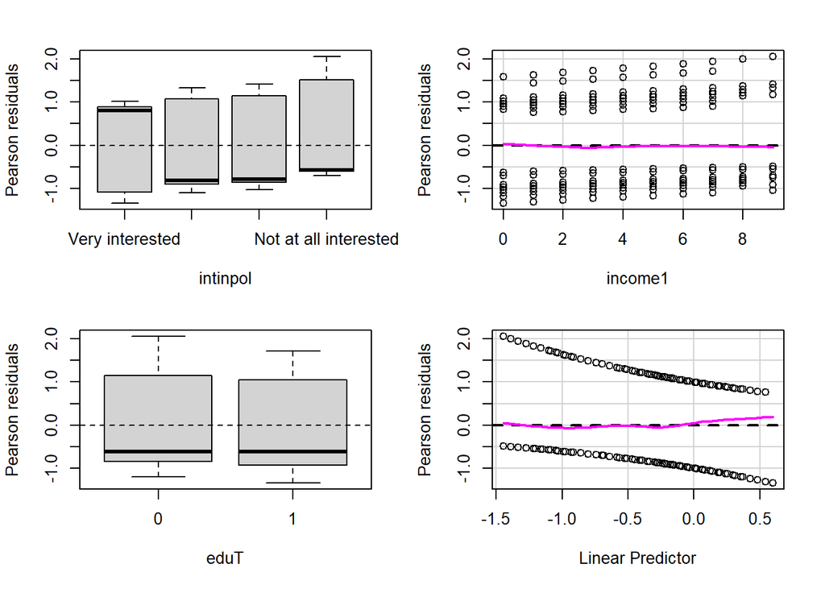

```
##          Test stat Pr(>|Test stat|)
## intinpol
## income1     0.3655           0.5455
## eduT
```

```r
car::residualPlots(logf)
```

Linearity check shows that our model predicts not really well (does not suit the data), this will be explained by further low accuracy.

# Model equation

is the following:

```r
library(equatiomatic)
```

```r
equatiomatic::extract_eq(logf, wrap = TRUE, terms_per_line = 3)
```

$$\begin{aligned}
\log\left[ \frac { P( \operatorname{Q211} = \operatorname{1} ) }{ 1 - P( \operatorname{Q211} = \operatorname{1} ) } \right] &= \alpha + \beta_{1}(\operatorname{intinpol}_{\operatorname{Somewhat\ interested}}) + \beta_{2}(\operatorname{intinpol}_{\operatorname{Not\ very\ interested}})\ + \\
&\quad \beta_{3}(\operatorname{intinpol}_{\operatorname{Not\ at\ all\ interested}}) + \beta_{4}(\operatorname{income1}) + \beta_{5}(\operatorname{eduT}_{\operatorname{1}})\ + \\
&\quad \epsilon
\end{aligned}$$

# Interpreting the coefficients

```r
library(broom)
tidy(logf)
```

```
## # A tibble: 6 x 5
##   term                          estimate std.error statistic       p.value
##   <chr>                            <dbl>     <dbl>     <dbl>         <dbl>
## 1 (Intercept)                     0.356     0.196       1.81 0.0695
## 2 intinpolSomewhat interested    -0.404     0.188      -2.15 0.0315
## 3 intinpolNot very interested    -0.536     0.186      -2.87 0.00405
## 4 intinpolNot at all interested  -1.29      0.217      -5.93 0.00000000294
## 5 income1                        -0.0575    0.0270     -2.13 0.0331
## 6 eduT1                           0.244     0.108       2.25 0.0245
```

```r
#augment(logf)
#glance(logf)
```

```r
exp(cbind(OR = coef(logf), confint(logf)))
```

```
##                                      OR     2.5 %    97.5 %
## (Intercept)                   1.4277497 0.9733762 2.1029471
## intinpolSomewhat interested   0.6675668 0.4608576 0.9636953
## intinpolNot very interested   0.5853727 0.4053375 0.8423304
## intinpolNot at all interested 0.2765914 0.1802280 0.4215937
## income1                       0.9441430 0.8953447 0.9952651
## eduT1                         1.2763087 1.0317961 1.5788207
```

When income increases by one unit, the odds change by a factor of 0.94, decrease by 1-0.94 = 6% [95% CI = 0.89; 0.99] When respondent’s education is higher, the odds change by a factor of 1.28, the chances are 1.27-1 = 27% higher [95% CI = 1.03; 1.57]

### margins

```r
library(margins)
m <- margins(logf, type = "response")
summary(m)
```

```
##                         factor     AME     SE       z      p   lower   upper
##                          eduT1  0.0580 0.0258  2.2426 0.0249  0.0073  0.1086
##                        income1 -0.0136 0.0063 -2.1413 0.0322 -0.0260 -0.0011
##  intinpolNot at all interested -0.2973 0.0489 -6.0781 0.0000 -0.3932 -0.2015
##    intinpolNot very interested -0.1324 0.0457 -2.8962 0.0038 -0.2220 -0.0428
##    intinpolSomewhat interested -0.1002 0.0462 -2.1670 0.0302 -0.1909 -0.0096
```

# Model quality

```r
library(pscl)
pR2(logf)
```

```
## fitting null model for pseudo-r2
```

```
##           llh       llhNull            G2      McFadden          r2ML
## -1.152428e+03 -1.178967e+03  5.307809e+01  2.251042e-02  3.011225e-02
##          r2CU
##  4.053385e-02
```

# Accuracy and commenting on the results

```r
bound <- floor((nrow(data)/4)*3)     #define 75% of training and test set (could be 50%, 60%)
set.seed(195455555)
df <- data[sample(nrow(data)), ]   #sample 400 random rows out of the data
df.train <- df[1:bound, ]              #get training set
df.test <- df[(bound+1):nrow(df), ]    #get test set

logff <- glm(Q211 ~ intinpol + income1 + eduT, data = data, family = "binomial")
```

```r
pred <- format(round(predict(logff, newdata = df.test, type = "response")))
accuracy <- table(pred, df.test[,"Q211"])
sum(diag(accuracy))/sum(accuracy)
```

```
## [1] 0.5760369
```

Accuracy of 0.57 is quite low.

```r
library(caret)
confusionMatrix(table(pred, df.test$Q211))
```

```
## Confusion Matrix and Statistics
##
##
## pred   0   1
##    0 227 162
##    1  22  23
##
##                Accuracy : 0.576
##                  95% CI : (0.528, 0.623)
##     No Information Rate : 0.5737
##     P-Value [Acc > NIR] : 0.4816
##
##                   Kappa : 0.0398
##
##  Mcnemar's Test P-Value : <2e-16
##
##             Sensitivity : 0.9116
##             Specificity : 0.1243
##          Pos Pred Value : 0.5835
##          Neg Pred Value : 0.5111
##              Prevalence : 0.5737
##          Detection Rate : 0.5230
##    Detection Prevalence : 0.8963
##       Balanced Accuracy : 0.5180
##
##        'Positive' Class : 0
##
```

We have sensitivity more higher that specificity, some troubles with predicting negative values.

Overall, in this project I created a binary logistic regression which predicts people’s polical actions with income, binary higher education and interest in politics. Although, the model does not predict very well, so some more explainable variables and observations must be added here.